# INSTRUCTIONS

- This is a group assignment.
- Submit your answer digitally as two files through Moodle:
  - An R markdown file (extension **Rmd**). Use the template provided to you and provide your answers (both code and text) below each question.
  - An **HTML** file “knitted” by RStudio including all the results and plots. More details on how to create these files were provided in class on week 3.
- Follow the Style Guide (available on Moodle). You can be penalized on up to 20% in each question for which you do not follow the Style Guide.
- Questions regarding the assignment should be posted exclusively on the respective discussion forum on Moodle.

## Deadline: Monday, March 10 at 23:59.

- Late submissions are not allowed

**Warning:** The detection of any form of plagiarism in your work means the assignment will be graded with ZERO points.

# Dating Platforms

Online dating platforms enable people to find new connections with the goal of developing personal, romantic, or sexual relationships. In some platforms individuals express their interest in others in multiple ways, including by “liking” them. “Liking” someone is an indication of interest that, in most platforms, is revealed to both individuals only if the “liking” is mutual, i.e., if the target individual also stated interest. In such cases we say there is a match.

For this assignment we are going to analyze “likes” issued by members in an online dating platform using tools learned in class. Answer each of the questions below the best you can. In case you find any ambiguity in the question, assume the most sensible option in you opinion, state your assumptions and proceed. In most cases ambiguity is by design.

## Data Description

The file `nda-dating-likes.RData` contains two `data.table`, each of them is described below.

### `dt.users`

| Field | Type | Description |
| --- | --- | --- |
| `user_id` | integer | user identification |
| `inviter_id` | integer | id of the user that invited this user to the platform |
| `gender` | string | gender |
| `birth_year` | integer | year of birth |
| `education` | integer | education |
| `approved_week` | date | week in which this user was approved to the platform |
| `height` | integer | height (in cm) |
| `children` | boolean | whether the user has children |
| `smoker` | boolean | whether the user smokes |
| `n_fb_friends` | integer | how many Facebook friends does the user have |

### `dt.likes`

| Field | Type | Description |
| --- | --- | --- |
| `sender_user_id` | integer | user identification of the sender of the like |
| `receiver_user_id` | integer | user identification of the receiver of the like |
| `week` | date | week in which the like was issued |

## Setup and data loading

Start by loading the required libraries and loading the likes data

```r
library(data.table)
library(ggplot2)
library(igraph)
library(patchwork)
load("nda-dating-likes.RData")
```

## Questions

### Invites Network `[10 points]`

This section contains questions related to the invites network.

1. *(Easy)* Build a directed graph representing the invites network: an individual A is connected to individual B if A invited B to the platform. What is the size of the longest chain? What is the clustering coefficient of this network? Justify. `[3 points]`

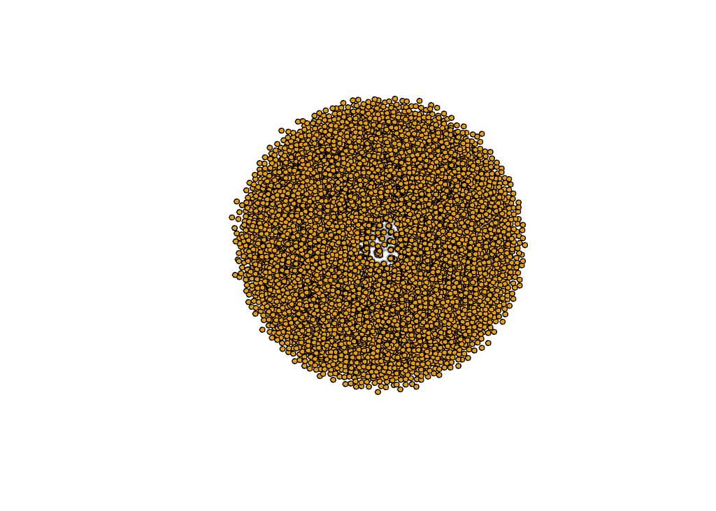

```r
# Plot all data point as a directed network
v.edges <- dt.users[, c("inviter_id", "user_id")]
#We are getting one node called NA, that is the people who were not invited
graph <- graph_from_data_frame(d = v.edges, directed = TRUE)
#Find the index of the node NA
na.node.index <- which(V(graph)$name == "NA")
#Delete NA from the graph
subgraph <- induced_subgraph(graph, -na.node.index)
plot(subgraph, vertex.label=NA, edge.arrow.size=0.3, vertex.size=4)
```

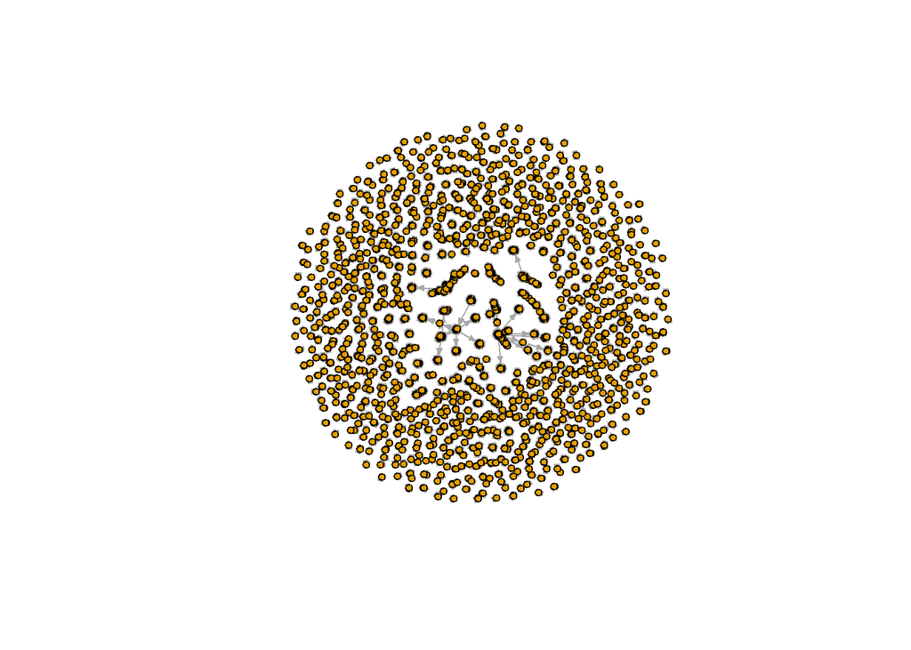

```r
# As the visualization is very dense, it is difficult to understand the
# connections between users, so we decided to plot a directed graph with only
# the users that are connected to others by an invitation.
# In other words, we eliminated the nodes that did not invite or were not
# invited by someone else.


#Plot the new directed graph without users that were not invited by others
dt.users.cleaned <- as.data.frame(dt.users[, c( "inviter_id", "user_id")])
dt.users.cleaned <- dt.users.cleaned[complete.cases(dt.users.cleaned), ]
invites.graph <- graph_from_data_frame(dt.users.cleaned, directed = TRUE)
plot(invites.graph, vertex.label = NA, vertex.size = 4, edge.arrow.size = 0.3)
```

```r
#Size of the longest chain
size.longest.chain <- diameter(subgraph)
cat("The size of the longest chain is calculated by the diameter and is",
    size.longest.chain,".", "\n")
```

```
## The size of the longest chain is calculated by the diameter and is 9 .
```

```r
#Clustering Coefficient Calculation
clustering.coefficient.global <- transitivity(subgraph, type = "global")
clustering.coefficient.average <- transitivity(subgraph, type = "average")
cat("The global clustering coefficient of this network is",
    clustering.coefficient.global, ".\n")
```

```
## The global clustering coefficient of this network is 0 .
```

```r
cat("The average clustering coefficient of this network is",
    clustering.coefficient.average, ".")
```

```
## The average clustering coefficient of this network is 0 .
```

##### SIZE OF THE LONGEST CHAIN

The size of the longest chain is 9 meaning that the longest directed path between any two nodes in the graph consists of 9 edges. So, in a plot with these much edges, it can mean that the network is not of extreme density and sparsity. This means that most of the people using the platform do not tend to invite new users.

##### CLUSTERING COEFFICIENT

The average clustering coefficient of a network is the degree to which its neighbors are linked among themselves, calculated by the average of the clustering coefficient of all nodes in a graph. In this case, the average clustering coefficient is 0, meaning that the nodes of this network do not form clusters with their neighbors. This result was expected as we are looking at a directed graph, were each node can be invited only 1 time. This means that, for instance, person A can invite person B and person C, creating an edge between A and B and A and C. However, it is impossible to have an edge between person B and C because each person can only be invited once although a user can invite several others. So, all nodes in the graph will have a clustering coefficient of 0.

2. *(Easy, once you get what you need to do)* Goel, Watts and Goldstein, in their paper entitled “The structure of online diffusion networks”, state that long cascades in diffusion networks happen very rarely in online networks. Do you think is also the case with the invites network in this online dating platform? Perform the analyses you deem necessary to answer this question with reasonable confidence. `[3 points]`

```r
# Find the connected components in a graph
l.connected.components <- components(subgraph)

# Calculate diameter for each connection
v.component.diameters <- c()
for (i in 1:length(l.connected.components$csize)) {
    component <- induced_subgraph(subgraph,
                                  which(l.connected.components$membership == i))
    v.component.diameter <- diameter(component)
    v.component.diameters <- c(v.component.diameters, v.component.diameter)
}

dt.value.counts <- table(v.component.diameters)
dt.value.counts
```

```
## v.component.diameters
##     0     1     2     3     4     5     6     7     9
## 11070   828   149    42    12     5     2     1     1
```

```r
cat("\n")
```

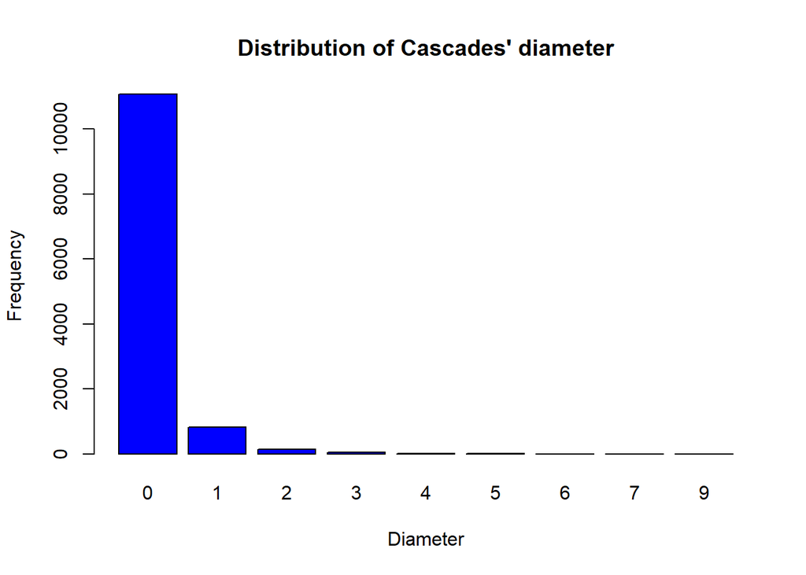

```r
barplot(dt.value.counts, main = "Distribution of Cascades' diameter",
        xlab = "Diameter", ylab = "Frequency",
        col = "blue")
```

```r
# Calculate the number of nodes in each connection
dt.component.size.counts <- table(l.connected.components$csize)
cat("component.size.counts")
```

```
## component.size.counts
```

```r
dt.component.size.counts
```

```
##
##     1     2     3     4     5     6     7     8     9    11    12    13    14
## 11070   677   203    69    31    18     9    10     3     4     2     2     2
##    20    21    35    38    71    96   127   152   300   336
##     1     1     1     1     1     1     1     1     1     1
```

Our interpretation of a cascade is each independent component that form the whole network. This is, starting in a node that entered on the platform without an invitation and ending in a node that did not invite anyone.

To analyse the frequency of long cascades in a diffusion network, in this case in the invited network, we calculated the diameter and size of all cascades.

The diameter is the the shortest longest path of a cascade and, as we can see in this network, there were 11070 cascades (91% of all cascades) with a diameter of 0 meaning that they were not invited not invited anyone. Moreover, 828 users joined the platform through an invitation and did not invite anyone else (7% of all cascades).

We consider a long cascade when the diameter is above or equal to 5. This only represents 9 cascades in total (5+2+1+1), which represents 0,07% (9/12110) of the cascades present in this network.

Furthermore, we decided to calculate the size of each cascade to see the density and strength of each. With this, we discovered that there were 677 cascades that have 2 nodes. Also, 80% of the nodes of this network are in a component of until 5 nodes.

So, to answer the question: Do you think is also the case with the invites network in this online dating platform? Based on our analysis, we conclude that this is the case with the online dating platform once the longest cascade has a diameter of 9 in a network of 15060 nodes.

3. *(Moderate)* Do you think the invites network exhibits homophily? In other words, do you think men are more likely to invite other men and women more likely to invite other women? What about in terms of age? Do members tend to invite members of a similar age? Please describe your overall approach to answering these questions and justify and explain each step of your answer. `[1 point]`

```r
# Absolute count of invitations by gender
dt.users$inviter.gender <- dt.users$gender[match(dt.users$inviter_id,
                                                 dt.users$user_id)]
men.inviting.men <- sum(dt.users$gender == 'Male' &
                          dt.users$inviter.gender == 'Male', na.rm = TRUE)
females.inviting.females <- sum(dt.users$gender == 'Female' &
                                  dt.users$inviter.gender == 'Female',
                                na.rm = TRUE)
men.inviting.female <- sum(dt.users$gender == 'Female' &
                             dt.users$inviter.gender == 'Male', na.rm = TRUE)
female.inviting.men <- sum(dt.users$gender == 'Male' &
                             dt.users$inviter.gender == 'Female', na.rm = TRUE)

cat("There are", men.inviting.men, "men inviting men and",
    men.inviting.female, "men inviting female . \n"  )
```

```
## There are 851 men inviting men and 309 men inviting female .
```

```r
cat("There are", female.inviting.men, "female inviting men and",
    females.inviting.females, "women inviting women \n"  )
```

```
## There are 527 female inviting men and 1263 women inviting women
```

```r
# Relative count of invitations by gender
dt.invited.users <- dt.users[!is.na(dt.users$inviter_id), ]
total.invitations <- nrow(dt.invited.users)
percentage.females.inviting.females <- (females.inviting.females /
                                          total.invitations)*100
percentage.men.inviting.men <- (men.inviting.men / total.invitations)*100
percentage.female.inviting.men <- (female.inviting.men / total.invitations)*100
percentage.men.inviting.female <- (men.inviting.female / total.invitations)*100

cat("From all invitations, ", percentage.females.inviting.females,"% were from",
    "women inviting women and", percentage.men.inviting.men, "% were from men",
    "inviting men. \n")
```

```
## From all invitations,  42.81356 % were from women inviting women and 28.84746 % were from men inviting men.
```

```r
cat("From all invitations,", percentage.female.inviting.men,"% were from women",
    "inviting men and ", percentage.men.inviting.female, "% were from men",
    "inviting women. \n")
```

```
## From all invitations, 17.86441 % were from women inviting men and  10.47458 % were from men inviting women.
```

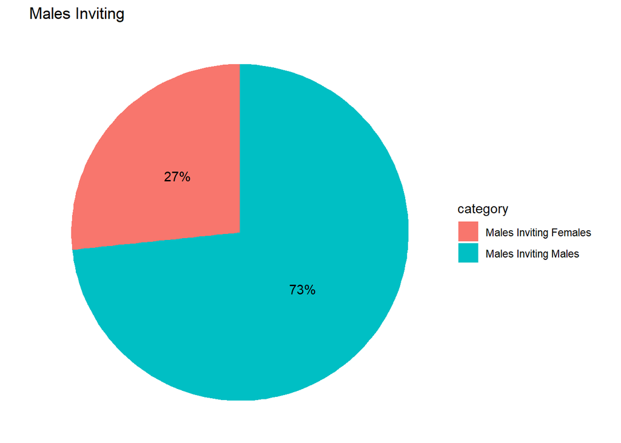

```r
# Plot histogram with invitation distribution by gender
percentage.men.invite.men <- (men.inviting.men) / (men.inviting.female +
                                                     men.inviting.men)*100
percentage.female.invite.female <- (females.inviting.females) /
  (females.inviting.females + female.inviting.men)*100
percentage.female.invite.men <- (female.inviting.men) /
  (females.inviting.females + female.inviting.men)*100
percentage.men.invite.female <- (men.inviting.female) / (men.inviting.female +
                                                           men.inviting.men)*100

df.males.data <- data.frame(
  category = c("Males Inviting Females", "Males Inviting Males"),
  percentage = c(percentage.men.invite.female, percentage.men.invite.men))

df.females.data <- data.frame(
  category = c("Females Inviting Females", "Females Inviting Males"),
  percentage = c(percentage.female.invite.female, percentage.female.invite.men))


# Plot pie chart for males
ggplot(df.males.data, aes(x = "", y = percentage, fill = category)) +
  geom_bar(stat = "identity", width = 1) +
  coord_polar("y") +
  theme_void() +
  ggtitle("Males Inviting") +
  geom_text(aes(label = paste0(round(percentage), "%")), position =
              position_stack(vjust = 0.5))
```

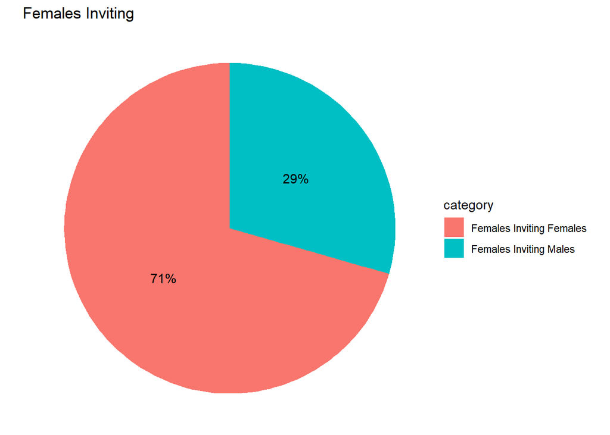

```r
# Plot pie chart for females
ggplot(df.females.data, aes(x = "", y = percentage, fill = category)) +
  geom_bar(stat = "identity", width = 1) +
  coord_polar("y") +
  theme_void() +
  ggtitle("Females Inviting") +
  geom_text(aes(label = paste0(round(percentage), "%")), position =
              position_stack(vjust = 0.5))
```

```r
# Delete outliers (user.id = 1994 has birth.year = 2078)
dt.users <- dt.users[user_id != 1994, ]

# Invitations by exactly the same age
dt.users$inviter_birth_year <- dt.users$birth_year[match(dt.users$inviter_id,
                                                         dt.users$user_id)]
same.age.invitations <- sum(dt.users$inviter_birth_year == dt.users$birth_year,
                            na.rm = TRUE)
percentage.same.age.invitations <- (same.age.invitations/total.invitations)*100

cat(same.age.invitations, "users were exactly the same age, which corresponds",
"to", percentage.same.age.invitations, "% .\n")
```

```
## 438 users were exactly the same age, which corresponds to 14.84746 % .
```

```r
# Average age difference between users and inviters
dt.users$age_difference <- abs(dt.users$birth_year - dt.users$inviter_birth_year)
dt.age.difference.data <- dt.users[!is.na(dt.users$age_difference), ]
average.age.difference <- mean(dt.age.difference.data$age_difference)

cat("From those who were invited, on average, they got invited by someone of",
    "around", round(average.age.difference), "years difference. \n")
```

```
## From those who were invited, on average, they got invited by someone of around 4 years difference.
```

```r
# Age bins of 4 years difference
age.bins <- seq(0, max(dt.users$age_difference, na.rm = TRUE) + 1, by = 4)
dt.users$age_group <- cut(dt.users$age_difference, breaks = age.bins,
                          labels = FALSE, include.lowest = TRUE)
dt.age.difference.data <- dt.users[!is.na(dt.users$inviter_birth_year), ]
invitation.counts <- table(dt.age.difference.data$age_group)

cat("We get that there were 1915 invitations between people with an age",
    "difference of between 0 and 4 years, 641 invitations between people with",
    "an age difference of between 4 and 8 years, and so on. \n")
```

```
## We get that there were 1915 invitations between people with an age difference of between 0 and 4 years, 641 invitations between people with an age difference of between 4 and 8 years, and so on.
```

```r
invitation.counts
```

```
##
##    1    2    3    4    5    6    7    8
## 1915  641  268   86   16   10    8    5
```

Homopholy is the tendency of nodes to connect with similar nodes in a network. This can be as “opportunity based” if there is only the opportunity for that or as “choice based” if there is the possibility of other different connections but still people choose to connect to those who share the same characteristics. In this case, dating platforms are “choice based” as people can connect with others that show a variety of different features.

Q: Do members tend to invite members of a similar age? A: Only 14.85% of the invitations were between users of exactly the same age. To perform a deeper and more insightful analysis, we calculated the mean age difference between users and inviters to find that the difference in age between them is of 4 years. So, we decided then to create age bins of width 4 and count how many users where invited by someone of that age range. With this, we concluded that there were 1915 users invited by someone with 0 to 4 years difference, 641 users invited by someone of 4 to 8 yeas difference, 268 users invited by someone of 8 to 12 years difference, and so on. There are 5 users invited by someone of 28 to 32 years difference, corresponding to the highest difference in age. So, we can conclude that people of similar age are more likely to invite people of similar age, once only a minority has a higher age difference.

Concluding, the invites network exhibits homopholy as, although people have the possibility to invite people of other gender and ages, most of them will still invite those with similar characteristics.

4. *(Make up question: You can skip any of the previous questions and answer this question instead.)* Describe and perform any additional analysis you want **using the invites network**. You will be graded by the creativity and correctness of the analysis, but also as a comparison to the best answers provided by other students. The best answers will have full points, while the other answers will be judged by comparison with the best answers. `[3 points]`

```r
# Calculate the % of information given for each characteristic, by year
dt.users$approved_week <- as.Date(dt.users$approved_week)
dt.users$year <- as.integer(format(dt.users$approved_week, "%Y"))
dt.users$month <- as.integer(format(dt.users$approved_week, "%m"))

df.diffusion.summary <- data.frame(year = integer(),
                                characteristic = character(),
                                adoption.rate = numeric(),
                                stringsAsFactors = FALSE)

characteristics <- c('education', 'smoker', 'children', 'height', 'gender',
                     'birth_year', 'n_fb_friends')

for (char in characteristics) {
  for (yr in sort(unique(dt.users$year[complete.cases(dt.users$year)]))) {
    data.year <- dt.users[dt.users$year == yr, ]
    data.year[[char]] <- as.integer(data.year[[char]])
    adoption.rate <- sum(!is.na(data.year[[char]])) / nrow(data.year)
    df.diffusion.summary <- rbind(df.diffusion.summary,
                               data.frame(year = yr, characteristic = char,
                                          adoption.rate = adoption.rate))
  }
}
print(df.diffusion.summary)
```

```
##    year characteristic adoption.rate
## 1  2012      education     1.0000000
## 2  2013      education     1.0000000
## 3  2014      education     1.0000000
## 4  2015      education     0.9982238
## 5  2016      education     0.3359976
## 6  2017      education     0.3739740
## 7  2012         smoker     0.3333333
## 8  2013         smoker     0.4011050
## 9  2014         smoker     0.4799176
## 10 2015         smoker     0.4387211
## 11 2016         smoker     0.2677620
## 12 2017         smoker     0.3113885
## 13 2012       children     0.6666667
## 14 2013       children     0.4408840
```

[output cut: 28 more lines]

```r
# We can see that in 2016 and 2017 there was a abrupt drop in the total
# characteristics provided by the new users. So, let's analyse these years.

# From those who entered in 2016 and 2017, if they were invited by someone else,
# did the inviter also provide all the information? Or not?

# So, we decided to analyse if these users were invited to the platform and if
# so, if the inviter provided all information. Moreover, we also compared if the
# user provided more or less than the invitee,

dt.users$invitation_status <- ifelse(dt.users$inviter_id != 0, "Invited",
                                     "Not Invited")
dt.year.2016.2017 <- dt.users[dt.users$year == 2016 | dt.users$year == 2017,]
dt.merged.data <- merge(dt.year.2016.2017, dt.users, by.x = "inviter_id",
                     by.y = "user_id", suffixes = c("_invitee", "_inviter"))
dt.merged.data$inviter_provided_all_info <- complete.cases(dt.merged.data[,
                  c("gender_inviter", "education_inviter", "smoker_inviter")])

dt.merged.data$num_characteristics_invitee <- rowSums(!is.na(dt.merged.data[,
                  c("gender_invitee", "education_invitee", "smoker_invitee")]))
dt.merged.data$num_characteristics_inviter <- rowSums(!is.na(dt.merged.data[,
                  c("gender_inviter", "education_inviter", "smoker_inviter")]))

dt.merged.data$characteristics_comparison <-
  ifelse(dt.merged.data$num_characteristics_invitee >
           dt.merged.data$num_characteristics_inviter,"More than Inviter",
                                              "Less than or Equal to Inviter")

dt.merged.data$percentage_characteristics_given <-
  (dt.merged.data$num_characteristics_invitee /
     dt.merged.data$num_characteristics_inviter) * 100
dt.merged.data
```

```
## Key: <inviter_id>
##       inviter_id user_id gender_invitee birth_year_invitee education_invitee
##            <int>   <int>         <char>              <num>             <int>
##    1:         61    3011           Male               1979                NA
##    2:         61    3056           Male               1988                 5
##    3:         61    3255           Male               1985                 4
##    4:         68    9541           Male               1987                 5
##    5:        102     335           Male               1984                 3
##   ---
## 1495:      14906   14997           Male               1987                 6
## 1496:      14937   15046           Male               1982                 5
## 1497:      14952   14980           Male               1975                 3
## 1498:      14986   14988           Male               1990                NA
## 1499:      14986   15052         Female               1987                NA
##       approved_week_invitee height_invitee children_invitee smoker_invitee
```

[output cut: 142 more lines]

```r
# Print the results
cat("There were", table(dt.users$invitation_status), "users invited to the",
"platform between 2016 and 2017. \n")
```

[output not shown]

```r
cat("Of those, ", table(dt.merged.data$inviter_provided_all_info)[["FALSE"]],
    "had an inviter who did not provid all info and ",
    table(dt.merged.data$inviter_provided_all_info)[["TRUE"]],
    "has an inviter who provided all info.\n")
```

```
## Of those,  701 had an inviter who did not provid all info and  798 has an inviter who provided all info.
```

```r
cat("So, ", table(dt.merged.data$characteristics_comparison)
    [["Less than or Equal to Inviter"]],
    "provided less than or equal information than the inviter and only",
    table(dt.merged.data$characteristics_comparison)[["More than Inviter"]],
    "provided more information than the inviter.\n")
```

```
## So,  1295 provided less than or equal information than the inviter and only 204 provided more information than the inviter.
```

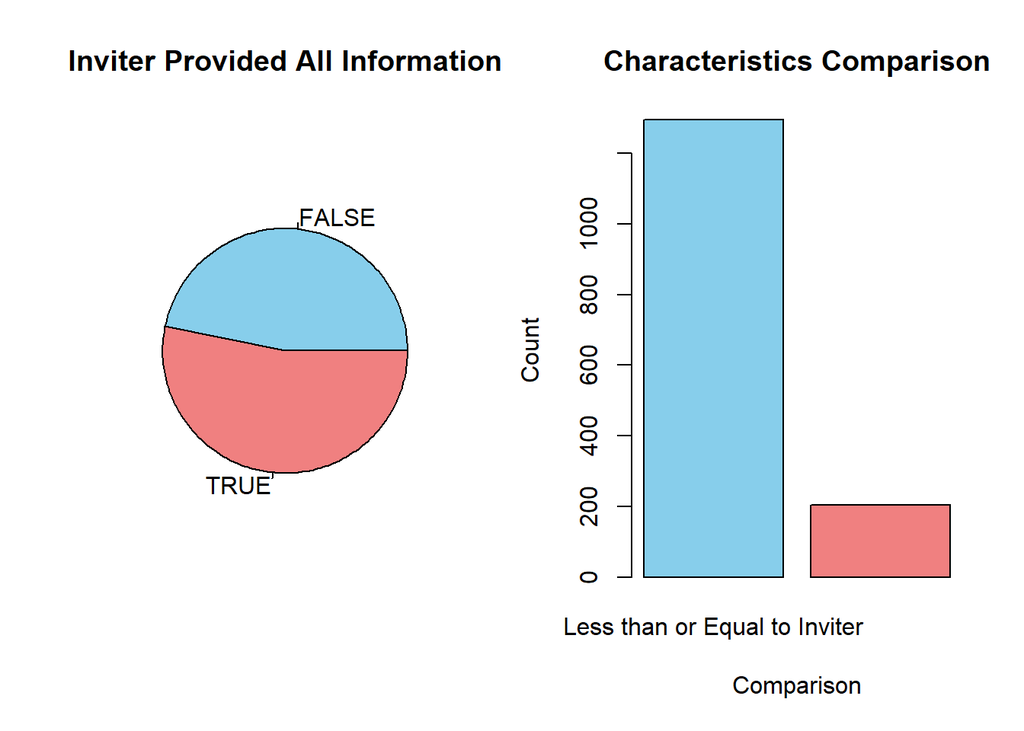

```r
# To better understand these values, we created a dataframe to store the results
df.results <- data.frame(
  User_ID = dt.merged.data$user_id,
  Invitation_Status = dt.users$invitation_status[match(dt.merged.data$user_id,
                                                       dt.users$user_id)],
  Inviter_Provided_All_Info = dt.merged.data$inviter_provided_all_info,
  Num_Characteristics_Invitee = dt.merged.data$num_characteristics_invitee,
  Num_Characteristics_Inviter = dt.merged.data$num_characteristics_inviter,
  Characteristics_Comparison = dt.merged.data$characteristics_comparison,
  Percentage_Characteristics_Given = dt.merged.data$percentage_characteristics_given
)

# Lastly, to better visualize our findings, we plotted the data
par(mfrow=c(1, 2))

# Pie chart for Inviter Provided All Information
pie(table(df.results$Inviter_Provided_All_Info),
    main="Inviter Provided All Information", col=c("skyblue", "lightcoral"))

# Bar plot for Characteristics Comparison
barplot(table(df.results$Characteristics_Comparison),
        main="Characteristics Comparison", xlab="Comparison", ylab="Count",
        col=c("skyblue", "lightcoral"))
```

```r
par(mfrow=c(1, 1))

cat("Now, it is easy to understand that there were more than half of the",
"inviters of those that entered the platform in 2016 and 2017 did provide all",
"information. However, the invitee provided less than or equal information",
"compared to the inviter. So,it is safe to say that dating platforms have been",
"facing a decreasing trend in the information users have been providing over",
"the years.")
```

[output not shown]

### Likes Network `[10 points]`

This section contains questions related to the likes network.

1. *(Easy)* Build a directed graph representing the likes network: an individual A is connected to individual B if A liked B. What is the clustering coefficient of this network? Justify. `[2.5 points]`

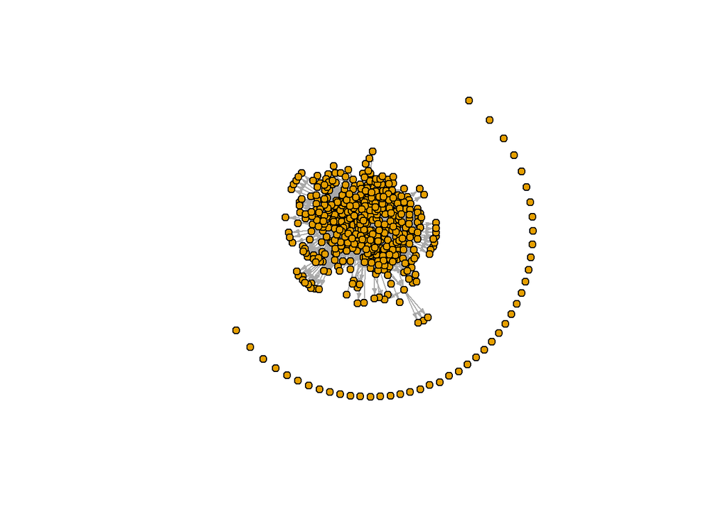

```r
# Remove the instances where sender_user_id is equal to receiver_user_id
# (assumed to be faulty)
dt.likes.clean <- dt.likes[!(sender_user_id == receiver_user_id), ]

# Create a directed graph representing the likes network
dt.likes.g <- dt.likes.clean[, list(sender_user_id, receiver_user_id)]
g.likes.directed <- graph_from_data_frame(d = dt.likes.g, directed = TRUE)

# Plot a sample (original graph is too big to plot)
sample.nodes <- sample(V(g.likes.directed), 500)
g.sample <- induced_subgraph(g.likes.directed, vids = sample.nodes)
plot(g.sample, vertex.label = NA, vertex.size = 5, edge.arrow.size = 0.3)
```

```r
# Compute the clustering coefficient
average.cluster.directed <- transitivity(g.likes.directed, type="average")
print("Clustering Coefficient:")
```

```
## [1] "Clustering Coefficient:"
```

```r
print(average.cluster.directed)
```

```
## [1] 0.0004102289
```

```r
# A: Clustering coefficient is 0.0004102289
```

The directed graph represents the likes network and it is made of individuals connected by directed edges, where an edge from individual A to individual B indicates that A liked B.

Before constructing this graph, we removed cases where the sender_user_id is equal to the receiver_user_id. We assumed that these self-liking interactions were some kind of error in the dataset or a bug in the application.

We then created a directed graph using the `graph_from_data_frame` function, using `directed = TRUE`. However due to the large size of the graph, we had problems plotting the entire network. So we created a sample of 500 nodes to have an idea of the structure of the network.

Looking at the sample graph we observe that there are nodes connected in the center of network forming clusters with lots of connections, but there is also a small portion of nodes disconnected from the center.

Furthermore, we calculated he clustering coefficient of our graph. On a local scale, the clustering coefficient of a node measures how well connected its neighbors are (as the number of existing connections divided by the possible connections). On a global scale, the clustering coefficient will describe the networks topology, more specifically, the tendency of nodes to form clusters. In the likes network, the computed average clustering coefficient is approximately 0.00041, a very low value. This low value suggests that, on average, individuals who like others don’t form highly interconnected clusters with each others’ liked individuals.

This finding reflects the nature of online dating, in which individual preferences (including sexuality) and interests, which vary a lot between people play a major role in the likes network. The observed structure reflects the heterogeneous nature of online dating. In online dating platforms, besides the wide range of user preferences and interests, geographic location can also influence choices. These factors when coupled together can lead to a more decentralized network where connections are driven by individual choices.

2. *(Moderate)* How many individuals “like” individuals of the same gender? Does this happen more between women or between men? `[2.5 points]`

```r
# Check if dt.users has duplicated user_id or missing gender
print("Number of rows with duplicated user_id in dt.users:")
```

```
## [1] "Number of rows with duplicated user_id in dt.users:"
```

```r
print(sum(duplicated(dt.users$user_id)))
```

```
## [1] 0
```

```r
print("Number of rows with missing gender in dt.users:")
```

```
## [1] "Number of rows with missing gender in dt.users:"
```

```r
print(sum(is.na(dt.users$gender)))
```

```
## [1] 0
```

```r
# Merge likes data table and gender data
dt.merged <- merge(dt.likes.clean, dt.users[, list(user_id, gender)],
                         by.x = "sender_user_id", by.y = "user_id")
setnames(dt.merged, "gender", "sender_gender")
dt.merged <- merge(dt.merged, dt.users[, list(user_id, gender)],
                         by.x = "receiver_user_id", by.y = "user_id")
setnames(dt.merged, "gender", "receiver_gender")

# Subset for same gender likes
dt.gender.same <- dt.merged[sender_gender == receiver_gender, ]

# Remove duplicate senders and users that like themselves
dt.gender.same.unique <- unique(dt.gender.same, by = "sender_user_id")

# Compute the number of individuals that like the same gender
t.gender.count.same <- table(dt.gender.same.unique$sender_gender)
print("Total individuals that like the same gender:")
```

```
## [1] "Total individuals that like the same gender:"
```

```r
lgb.count <- sum(t.gender.count.same)
print(lgb.count)
```

```
## [1] 423
```

```r
print("Number of individuals that like the same gender, by gender:")
```

```
## [1] "Number of individuals that like the same gender, by gender:"
```

```r
print(t.gender.count.same)
```

```
##
## Female   Male
##    166    257
```

```r
# Check if all the users in dt.users are in dt.likes (before calc. proportions)
print("Number of users in dt.users not in dt.likes:")
```

```
## [1] "Number of users in dt.users not in dt.likes:"
```

```r
number.users <- dt.users[!((dt.users$user_id %in% dt.likes$receiver_user_id) |
                          (dt.users$user_id %in% dt.likes$sender_user_id)), .N]
print(number.users)
```

```
## [1] 0
```

```r
# Compute proportions
print("Proportion of individuals that like the same gender:")
```

```
## [1] "Proportion of individuals that like the same gender:"
```

```r
user.count <- dt.users[, .N]
print(lgb.count / user.count)
```

```
## [1] 0.02808951
```

```r
print("Proportion of individuals that like the same gender by gender:")
```

```
## [1] "Proportion of individuals that like the same gender by gender:"
```

```r
t.gender.count.all <- table(dt.users$gender)
t.gender.proportion.same <- t.gender.count.same / t.gender.count.all
print(t.gender.proportion.same)
```

```
##
##     Female       Male
## 0.01996872 0.03809665
```

```r
# A: Male - 257 (3.8%); Female - 166 (2%); Total - 423 (2.81%)
```

Before discussing results, it is important to discuss an assumption made in our solution. We assumed that the number of individuals that like individuals of the same gender, are individuals who sent like to other individuals of their gender. This means that, for example, a man receives likes from another man, that man would not be counted. This assumption could be contested, as most dating platforms would only allow other users of the same gender to see and like a profile, if the individual would state same gender preference. But due to lack of contextual information about the data source, we adopted this simpler approach. This assumption more likely does not affect our final conclusions, as only some rare cases are affected.

Regarding the results, we found that a total of 423 individuals like individuals of the same gender. This constitutes approximately 2.81% of users. Breaking it down by gender, 166 out of the 423 individuals counted are females, while the remaining 257 are males. So, in absolute terms, there are 91 more males who like males than females who like females.

It is important to put this number into context, by calculating it in proportion to the total number of males and females. After calculating the proportion, it was found that approximately 3.81% of males like other males, compared to 2% of females. Taking into account these proportions, we can make the following conclusions:

1. The number of individuals that like other individuals is low in the dataset. This is consistent with what we would expect in a dating platform. This low number of individuals also goes in line with the hypothesis we proposed in question 1 to explain the low clustering coefficient in the likes network.
2. Among the individuals that like the same gender, more individuals are male than female. In percentage of the total number of users of each gender, there are more males that like the same gender than females, indicating that liking the same gender is more common in males.
3. *(Easy)* Build an undirected graph representing the matches network: an individual A is connected to individual B if A liked B and B liked A. What is the clustering coefficient of this network? Justify. Hint: the function `as.undirected` transforms a directed graph into an undirected graph; it can transform only the mutually directed edges in undirected edges. `[2.5 points]`

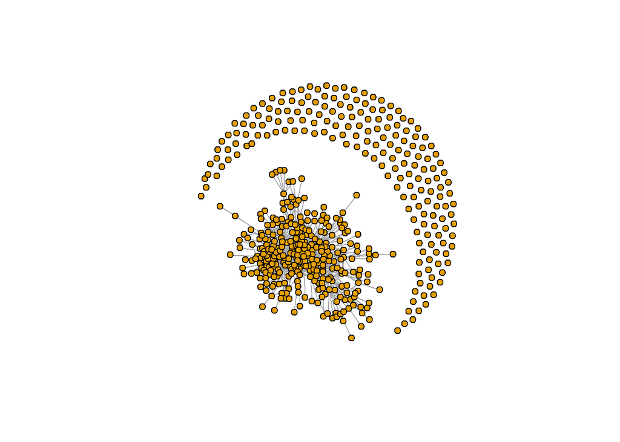

```r
# Transform the directed graph built in question 1 into an undirected graph
g.likes.undirected <- as.undirected(g.likes.directed, mode = "mutual")
vertices.filter <- V(g.likes.undirected)[degree(g.likes.undirected) != 0]
g.matches <- induced_subgraph(g.likes.undirected, vids = vertices.filter)

# Plot a sample (original graph is too big to plot)
sample.nodes <- sample(V(g.matches), 500)
g.sample <- induced_subgraph(g.matches, vids = sample.nodes)
plot(g.sample, vertex.label = NA, vertex.size = 5, edge.arrow.size = 0.3)
```

```r
# Compute the clustering coefficient
average.cluster.undirected <- transitivity(g.matches, type="average")
print("Clustering Coefficient:")
```

```
## [1] "Clustering Coefficient:"
```

```r
print(average.cluster.undirected)
```

```
## [1] 0.0002786879
```

```r
# A: Clustering coefficient is 0.0002786879
```

The matches network represents individuals who have mutually liked each other. We used the function as.undirected() to create the graph of matches. Here an edge exists between two nodes if both individuals have liked each other’s profiles.

After filtering out isolated nodes (individuals who have no connections), we obtained the matches network. We also opted to visualize a sample of 500 nodes and their connections. This provided an overview of the network structure.

In the matches network, the computed average clustering coefficient is approximately 0.00028. This indicates a very low level of clustering in the network.

The low clustering coefficient suggests that, on average, individuals who reciprocate the likes between each other are not highly interconnected with the other person mutual connections. This could be due to the various factors cited in the previous answer, such as the heterogeneity in preferences and interests.

It is also worth noting that the clustering coefficient is lower than in the directed network. One explanation for this could be the fact that in the directed network, it would be possible for an heterosexual individual to like an homosexual individual of the other gender (or vice-versa). Of course, these two wouldn’t match. Subsequently, the homosexual user would like other users, that could have a connection with the first user. This group of connections would not be present in the matches network, as it would remove any connection that is not reciprocated.

4. *(Moderate)* A recent research article gathered significant attention for claiming that, contrary to decades of prior research, most real life networks are not scale-free (i.e., the degree distribution does no not follow a power law). Based on the Quanta Magazine article (not on the original research paper) linked below, how do you classify the network of matches? Does it resemble a random network, a free-scale network, or a mixed network? Justify your answer. `[2.5 points]`

   Article: http://bit.ly/2BwobR1

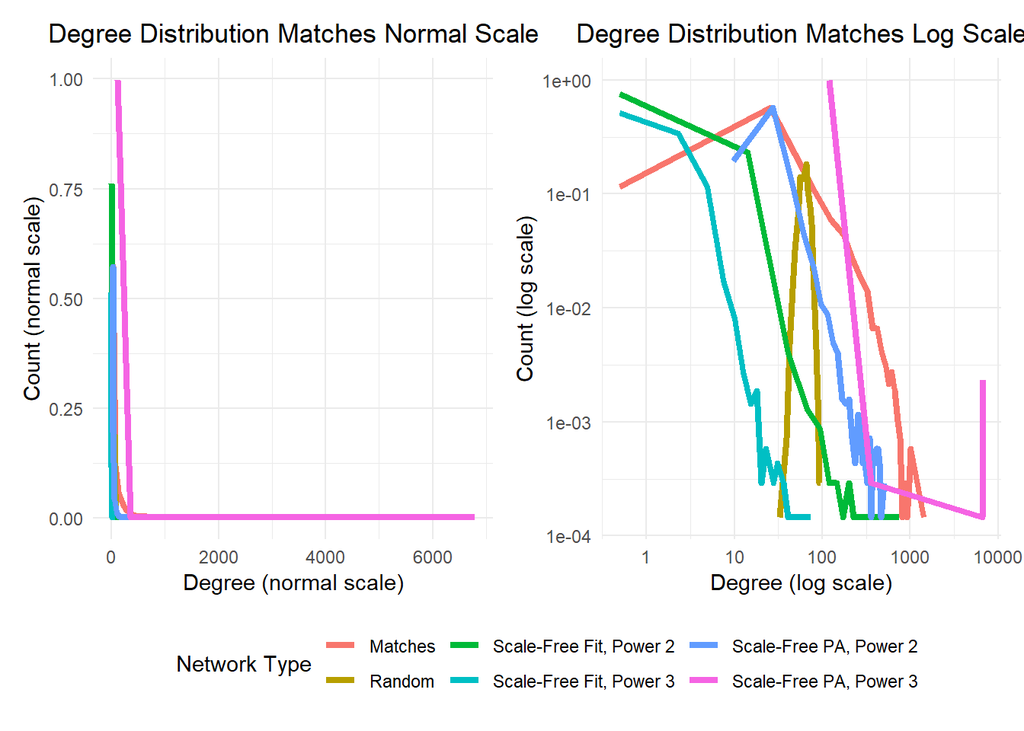

```r
# Store the number of Vertices and Edges of the matches graph in variables
number.vertices <- vcount(g.matches)
number.edges <- ecount(g.matches)

# Build a random network
g.random <- sample_gnm(number.vertices, number.edges)

# Build the scale-free networks using preferential attachment
# Define the m parameter as n edges / n vertices to get a comparable network
m.pref <- median(degree(g.matches))
g.sf.pa.p2 <- sample_pa(number.vertices, power = 1, m = m.pref,
                             directed = FALSE)
g.sf.pa.p3 <- sample_pa(number.vertices, power = 3, m = m.pref,
                             directed = FALSE)

# Build the scale-free networks using the fitness model
g.sf.fit.p2 <- sample_fitness_pl(number.vertices, number.vertices,
                                    exponent.in = -1, exponent.out = 2)
g.sf.fit.p3 <- sample_fitness_pl(number.vertices, number.vertices,
                                    exponent.in = -1, exponent.out = 3)

# Build the pure networks with arbitrary number of vertices and edges
g.type.random <- sample_gnp(10000, p = 0.1)
g.type.sf.p2 <- sample_pa(10000, power = 2, m = 7)
g.type.sf.p3 <- sample_pa(10000, power = 3, m = 7)

# Function to bin and normalize the degree distribution (use a default 30 bins)
bin.and.normalize <- function(network, network.name, number.of.bins = 30) {
  degrees <- degree(network)
  max.degree <- max(degrees)
  log.breaks <- log10(seq(1, max.degree, length.out = number.of.bins))
  bins <- c(0, 10^log.breaks)
  binned.data <- hist(degrees, breaks = bins, plot = FALSE)

  dt <- data.table(
    degree = binned.data$mids,
    count = binned.data$counts / sum(binned.data$counts),
    network = network.name
  )
# Remove NaNs and infinite values
dt <- dt[!is.nan(degree) & !is.nan(count) & degree > 0 & count > 0]

  return(dt)
}

# Apply the function to the networks, and join all data tables

dt.degree.match <- bin.and.normalize(g.matches, "Matches")
dt.degree.random <- bin.and.normalize(g.random, "Random")
dt.degree.pa.p2 <- bin.and.normalize(g.sf.pa.p2, "Scale-Free PA, Power 2")
dt.degree.pa.p3 <- bin.and.normalize(g.sf.pa.p3, "Scale-Free PA, Power 3")
dt.degree.fit.p2 <- bin.and.normalize(g.sf.fit.p2, "Scale-Free Fit, Power 2")
dt.degree.fit.p3 <- bin.and.normalize(g.sf.fit.p3, "Scale-Free Fit, Power 3")
dt.degree.type.random <- bin.and.normalize(g.type.random, "Random Type")
dt.degree.type.sf.p2 <- bin.and.normalize(g.type.sf.p2, "Scale-Free Type, Power 2")
dt.degree.type.sf.p3 <- bin.and.normalize(g.type.sf.p3, "Scale-Free Type, Power 3")
dt.degree.all <- rbind(dt.degree.match, dt.degree.random, dt.degree.pa.p2,
                       dt.degree.pa.p3, dt.degree.fit.p2, dt.degree.fit.p3,
                       dt.degree.type.random, dt.degree.type.sf.p2,
                       dt.degree.type.sf.p3)

# Plot the degree distribution for the matches network and comparable networks
l.to.plot <- list("Matches", "Random", "Scale-Free PA, Power 2",
                  "Scale-Free PA, Power 3", "Scale-Free Fit, Power 2",
                  "Scale-Free Fit, Power 3", "Random Type",
                  "Scale-Free Type, Power 2", "Scale-Free Type, Power 3")
l.to.plot <- list("Matches", "Random", "Scale-Free PA, Power 2",
                  "Scale-Free PA, Power 3", "Scale-Free Fit, Power 2",
                  "Scale-Free Fit, Power 3")

plot.1 <- ggplot(dt.degree.all[network %in% l.to.plot], aes(x = degree,
                                                            y = count,
                                                            color = network)) +
  geom_line(linewidth = 1.5) +
  theme_minimal() +
  labs(title = "Degree Distribution Matches Normal Scale",
       x = "Degree (normal scale)",
       y = "Count (normal scale)",
       color = "Network Type") +
  theme(legend.position = "none", plot.title = element_text(hjust = 0.5))

plot.2 <- ggplot(dt.degree.all[network %in% l.to.plot], aes(x = degree,
                                                            y = count,
                                                            color = network)) +
  geom_line(linewidth = 1.5) +
  scale_x_log10() + scale_y_log10() +
  theme_minimal() +
  labs(title = "Degree Distribution Matches Log Scale",
       x = "Degree (log scale)",
       y = "Count (log scale)",
       color = "Network Type") +
  theme(legend.position = "none", plot.title = element_text(hjust = 0.5))

print((plot.1 | plot.2) + plot_layout(guides = "collect") &
        theme(legend.position = "bottom"))
```

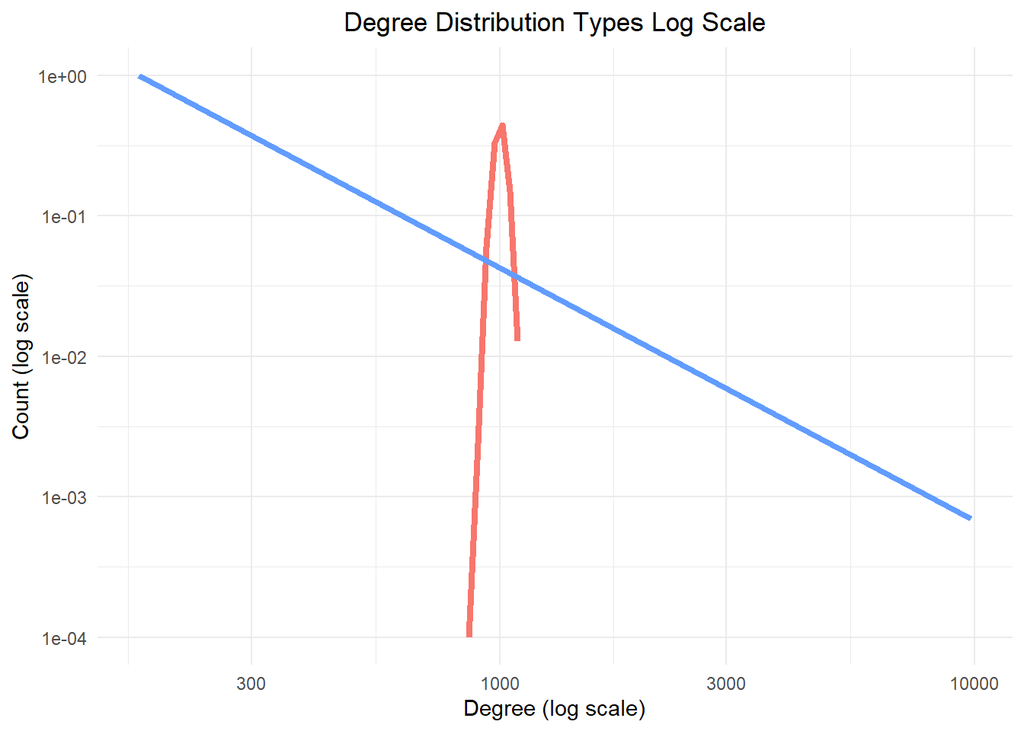

```r
# Plot the degree distribution for the artificial networks
l.to.plot <- list("Random Type", "Scale-Free Type, Power 2",
                  "Scale-Free Type, Power 3")

ggplot(dt.degree.all[network %in% l.to.plot], aes(x = degree, y = count,
                                                  color = network)) +
  geom_line(linewidth = 1.5) +
  scale_x_log10() + scale_y_log10() +
  theme_minimal() +
  labs(title = "Degree Distribution Types Log Scale",
       x = "Degree (log scale)",
       y = "Count (log scale)",
       color = "Network Type") +
  theme(legend.position = "none", plot.title = element_text(hjust = 0.5))
```

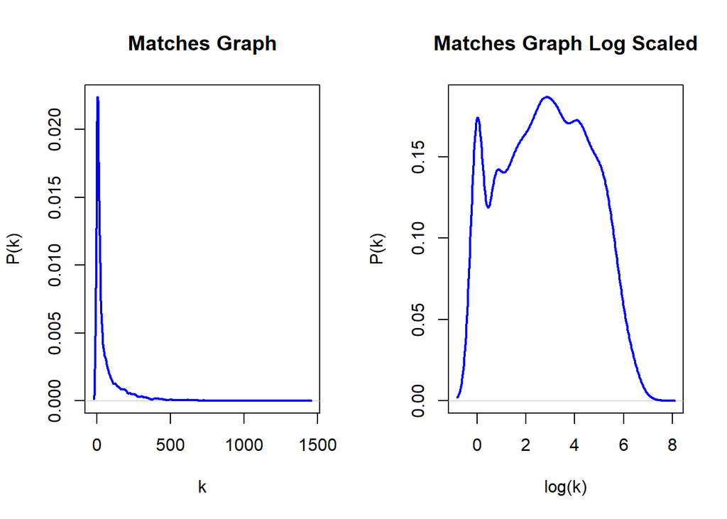

```r
# More in depth plots for the matches, scale-free pa power 2 and random networks
par(mfrow=c(1,2),  mar=c(5, 4, 4, 2) + 0.1)
plot(density(degree(g.matches)), xlab = "k", ylab = "P(k)",
     main = "Matches Graph", type = "n")
lines(density(degree(g.matches)), col = "blue", lwd = 2)
plot(density(log(degree(g.matches))), xlab = "log(k)", ylab = "P(k)",
     main = "Matches Graph Log Scaled", type = "n")
lines(density(log(degree(g.matches))), col = "blue",lwd = 2)
```

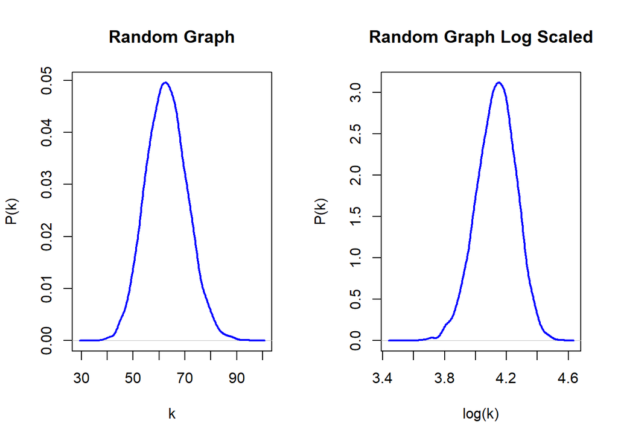

```r
par(mfrow=c(1,2),  mar=c(5, 4, 4, 2) + 0.1)
plot(density(degree(g.random)), xlab = "k", ylab = "P(k)",
     main = "Random Graph", type = "n")
lines(density(degree(g.random)), col = "blue", lwd = 2)
plot(density(log(degree(g.random))), xlab = "log(k)", ylab = "P(k)",
     main = "Random Graph Log Scaled", type = "n")
lines(density(log(degree(g.random))), col = "blue",lwd = 2)
```

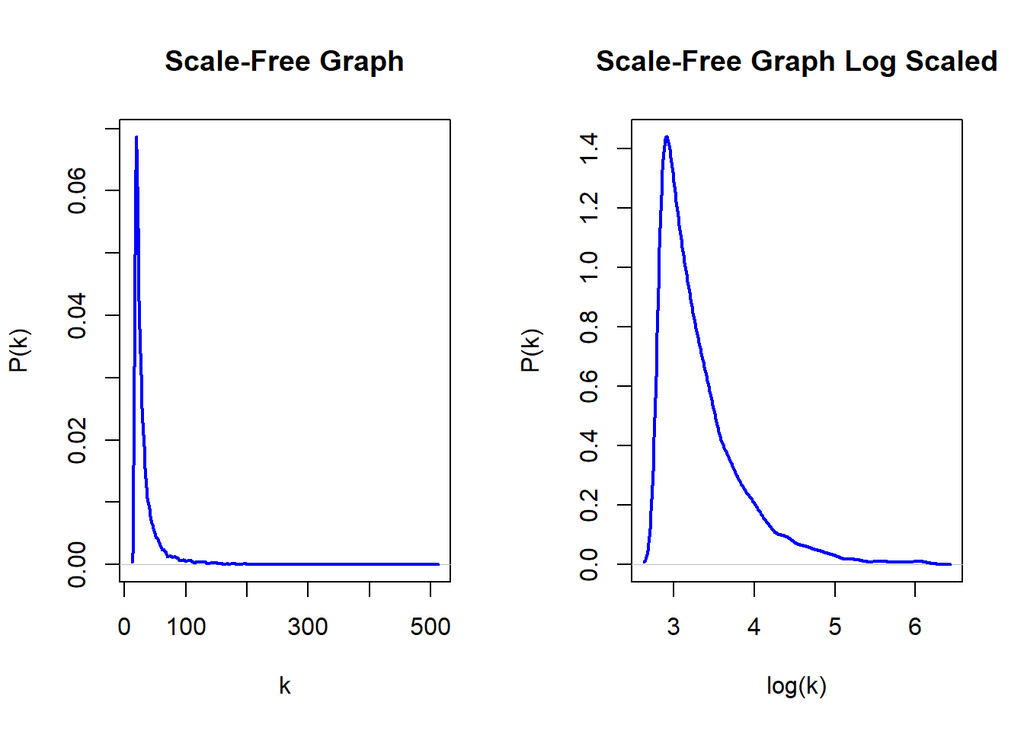

```r
par(mfrow=c(1,2),  mar=c(5, 4, 4, 2) + 0.1)
plot(density(degree(g.sf.pa.p2)), xlab = "k", ylab = "P(k)",
     main = "Scale-Free Graph", type = "n")
lines(density(degree(g.sf.pa.p2)), col = "blue", lwd = 2)
plot(density(log(degree(g.sf.pa.p2))), xlab = "log(k)", ylab = "P(k)",
     main = "Scale-Free Graph Log Scaled", type = "n")
lines(density(log(degree(g.sf.pa.p2))), col = "blue",lwd = 2)
```

After building the networks, we will plot the degree distributions together, both in normal and in the log-log scale, to assess the type of the matches network based on the similarity with the other artificially built networks.

Outcomes of the test:

Because of these results, we could argue that the matches network can be considered a mixed network.

5. *(Make-up question: You can skip any of the previous questions and answer this question instead.)* Describe and perform any additional analysis you want **using the any network originated from the likes data.** You will be graded by the creativity and correctness of the analysis, but also as a comparison to the best answers provided by other students. The best answers will have full points, while the other answers will be judged by comparison with the best answers. `[2.5 points]`

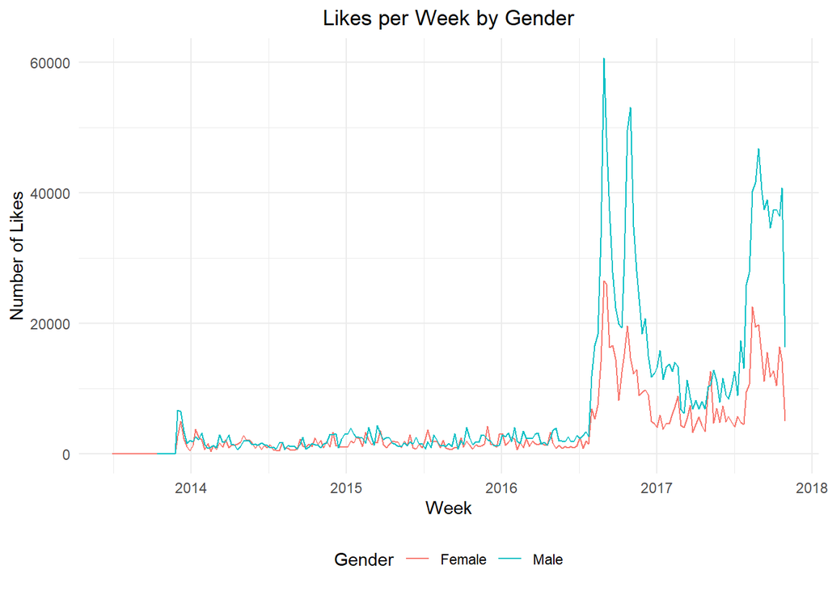

```r
#Aggregating likes per week and gender
dt.likes.month.gender <- dt.merged[, .(likes = .N), by = .(week, sender_gender)]

# Plot likes per month and gender
ggplot(dt.likes.month.gender, aes(x = week, y = likes, color = sender_gender)) +
  geom_line() + theme_minimal() +
  labs(title = "Likes per Week by Gender",
       x = "Week",
       y = "Number of Likes",
       color = "Gender") +
  theme(legend.position = "bottom", plot.title = element_text(hjust = 0.5))
```

In this question, we aim to conduct a temporal analysis of the likes data table, focusing on the aggregated likes sent each week and the resulting temporal patterns. Our objective is to uncover any discernible trends or fluctuations over time within this dataset. Additionally, we will explore how these patterns vary when the data is segmented by gender.

A observation in this time is the widening gap between likes sent by female and male users post mid-2016, with male senders becoming predominant. Furthermore, during periods of heightened activity the disparity in likes sent by gender accentuates, with male users nearly and over doubling the engagement levels.

In conclusion, this temporal analysis highlights the trajectory in user engagement within the app, from its inception to the later stages. The observed trends offer valuable insights into user behavior dynamics, and seasonal fluctuations.